# Experiment 3

2024-11-3

# The results of the model

Model structure: `brm(Selection ~ CategoryType + (CategoryType | Participant) + (1 | item)`

`Selection` had four levels: “Elaine right”,“Akira right”, “Both”, and “Neither”. The model predicted the log-odds of each choice as a function of `CategoryType`.

`CategoryType` had three levels: “Natural”, “Abstract” (Value) and “Artifact”.

`Participant`: There were 50 participants, each with 18 data points total (6 per `CategoryType`). the model included a random slope of category type per participant. This both takes into account the nested structure of the data and allows for the estimation of individual probabilities per `CategoryType`.

This is another simple model that will serve as the model we use for the sensitivity analysis - we should dicuss priors. We can use the data from experiment 2, potentially.

I also want to discuss this experiment to make sure I am understanding it, since we have mostly discussed the first two experiments. I have some data from last year that shows two data files, which I tidied.

| Parameter | Median | CI_low | CI_high | pd | ROPE_Percentage | Rhat | ESS |
| --- | --- | --- | --- | --- | --- | --- | --- |
| b_muBoth_Intercept | -0.06 | -0.62 | 0.46 | 0.59 | 0.50 | 1 | 2075 |
| b_muElaineright_Intercept | 0.89 | 0.22 | 1.53 | 0.99 | 0.00 | 1 | 1586 |
| b_muNeither_Intercept | -6.59 | -7.69 | -5.45 | 1.00 | 0.00 | 1 | 2499 |
| b_muBoth_CategoryTypenatural_kind | -0.15 | -0.76 | 0.43 | 0.69 | 0.42 | 1 | 4009 |
| b_muBoth_CategoryTypevalue | 0.13 | -0.40 | 0.67 | 0.69 | 0.48 | 1 | 3993 |
| b_muElaineright_CategoryTypenatural_kind | 0.39 | -0.43 | 1.18 | 0.84 | 0.23 | 1 | 1974 |
| b_muElaineright_CategoryTypevalue | -0.78 | -1.52 | -0.06 | 0.98 | 0.03 | 1 | 2032 |
| b_muNeither_CategoryTypenatural_kind | 0.65 | -0.26 | 1.56 | 0.91 | 0.14 | 1 | 4935 |
| b_muNeither_CategoryTypevalue | 0.69 | -0.20 | 1.62 | 0.93 | 0.11 | 1 | 4145 |

## The conditional effects based on the model

This plot and table were generated from the model using the `conditional_effects` function in R. The function just does the addition needed and conversion to probability as a convenience.

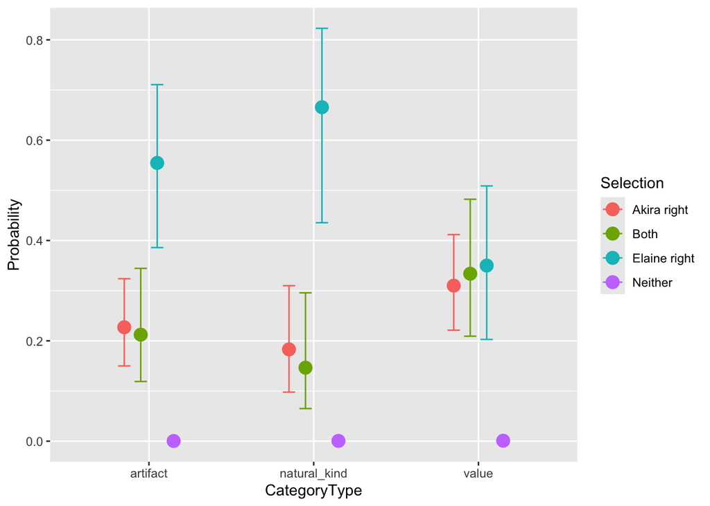

| CategoryType | Akira right | Both | Elaine right | Neither |
| --- | --- | --- | --- | --- |
| artifact | 0.23 [0.15 - 0.32] | 0.21 [0.12 - 0.34] | 0.55 [0.39 - 0.71] | 0 [0 - 0] |
| natural_kind | 0.18 [0.1 - 0.31] | 0.15 [0.06 - 0.3] | 0.67 [0.44 - 0.82] | 0 [0 - 0] |
| value | 0.31 [0.22 - 0.41] | 0.33 [0.21 - 0.48] | 0.35 [0.2 - 0.51] | 0 [0 - 0] |

# Pairwise comparisons

## Elaine is right between answer choices

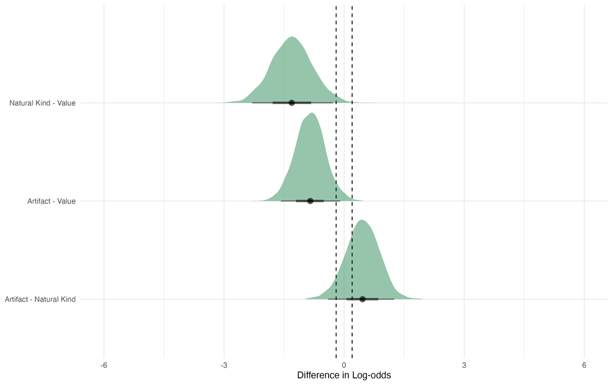

| Comparison | Effect | Compelling_difference |
| --- | --- | --- |
| Elaine right_natural_kind_Elaine right_value | -1.31 [-2.33 - -0.31] | Yes |
| Elaine right_artifact_Elaine right_value | -0.85 [-1.57 - -0.1] | Yes |
| Elaine right_artifact_Elaine right_natural_kind | 0.46 [-0.34 - 1.31] | No |

## Akira is right between answer choices

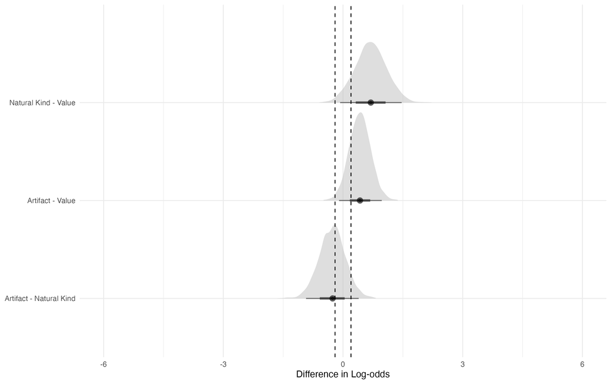

| Comparison | Effect | Compelling_difference |
| --- | --- | --- |
| Akira right_natural_kind_Akira right_value | 0.7 [-0.12 - 1.43] | No |
| Akira right_artifact_Akira right_value | 0.43 [-0.15 - 0.91] | No |
| Akira right_artifact_Akira right_natural_kind | -0.27 [-0.9 - 0.42] | No |

## Both are right is right between answer choices

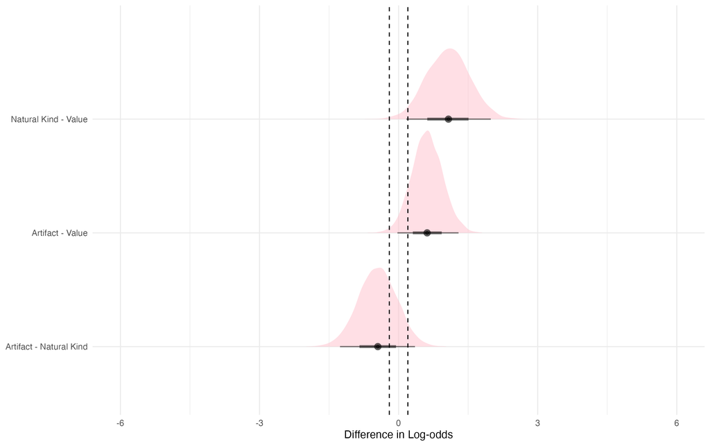

| Comparison | Effect | Compelling_difference |
| --- | --- | --- |
| Both_natural_kind_Both_value | 1.07 [0.14 - 1.95] | Yes |
| Both_artifact_Both_value | 0.62 [-0.05 - 1.26] | No |
| Both_artifact_Both_natural_kind | -0.45 [-1.26 - 0.35] | No |

## Within Natural Kinds

*For these, I left out the pairwise comps with neither, given it was always near 0*

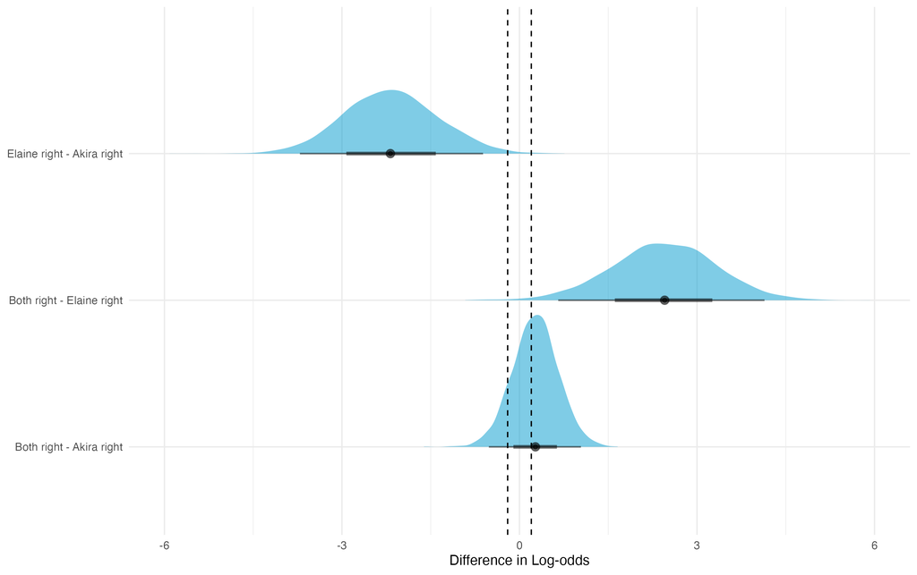

| Comparison | Effect | Compelling_difference |
| --- | --- | --- |
| Elaine right_natural_kind_Akira right_natural_kind | -2.17 [-3.73 - -0.63] | Yes |
| Both_natural_kind_Elaine right_natural_kind | 2.44 [0.6 - 4.08] | Yes |
| Both_natural_kind_Akira right_natural_kind | 0.27 [-0.57 - 0.97] | No |

## Within value

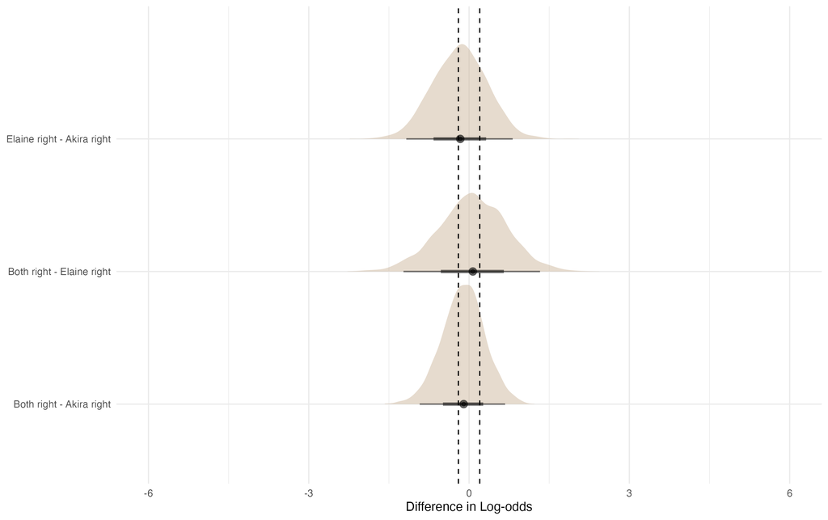

| Comparison | Effect | Compelling_difference |
| --- | --- | --- |
| Elaine right_value_Akira right_value | -0.17 [-1.2 - 0.78] | No |
| Both_value_Elaine right_value | 0.06 [-1.26 - 1.27] | No |
| Both_value_Akira right_value | -0.11 [-0.9 - 0.69] | No |

## Within artifact

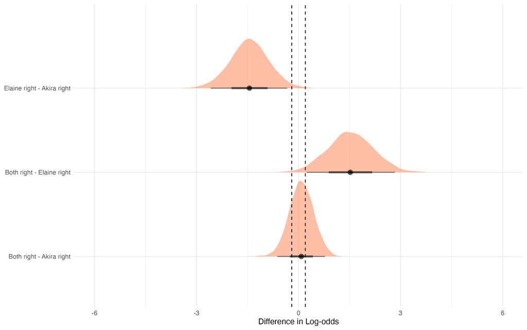

| Comparison | Effect | Compelling_difference |
| --- | --- | --- |
| Elaine right_artifact_Akira right_artifact | -1.45 [-2.55 - -0.32] | Yes |
| Both_artifact_Elaine right_artifact | 1.53 [0.25 - 2.84] | Yes |
| Both_artifact_Akira right_artifact | 0.08 [-0.62 - 0.77] | No |

## Sensitivity Analysis

| Parameter | Median | CI_low | CI_high | pd | ROPE_Percentage | Rhat | ESS |
| --- | --- | --- | --- | --- | --- | --- | --- |
| b_muBoth_Intercept | -0.21 | -0.93 | 0.41 | 0.74 | 0.37 | 1 | 1703 |
| b_muElaineright_Intercept | 1.19 | 0.33 | 2.09 | 1.00 | 0.00 | 1 | 1535 |
| b_muNeither_Intercept | -2.73 | -4.36 | -1.63 | 1.00 | 0.00 | 1 | 1356 |
| b_muBoth_CategoryTypenatural_kind | -0.07 | -0.91 | 0.76 | 0.56 | 0.35 | 1 | 2926 |
| b_muBoth_CategoryTypevalue | 0.25 | -0.45 | 0.95 | 0.77 | 0.33 | 1 | 2729 |
| b_muElaineright_CategoryTypenatural_kind | 1.54 | 0.06 | 3.12 | 0.98 | 0.01 | 1 | 1410 |
| b_muElaineright_CategoryTypevalue | -0.75 | -1.85 | 0.38 | 0.92 | 0.10 | 1 | 1633 |
| b_muNeither_CategoryTypenatural_kind | 0.52 | -1.29 | 2.16 | 0.74 | 0.16 | 1 | 1812 |
| b_muNeither_CategoryTypevalue | 0.20 | -1.30 | 1.82 | 0.62 | 0.20 | 1 | 2257 |

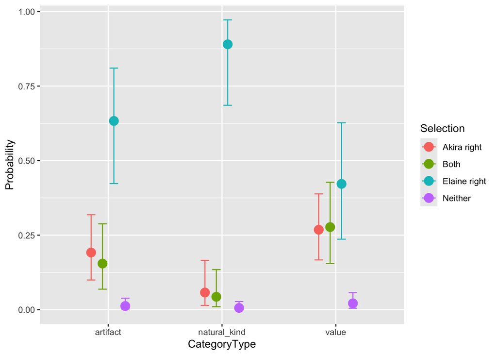

| CategoryType | Akira right | Both | Elaine right | Neither |
| --- | --- | --- | --- | --- |
| artifact | 0.19 [0.1 - 0.32] | 0.15 [0.07 - 0.29] | 0.63 [0.42 - 0.81] | 0.01 [0 - 0.04] |
| natural_kind | 0.06 [0.01 - 0.17] | 0.04 [0.01 - 0.13] | 0.89 [0.69 - 0.97] | 0.01 [0 - 0.03] |
| value | 0.27 [0.17 - 0.39] | 0.28 [0.16 - 0.43] | 0.42 [0.24 - 0.63] | 0.02 [0 - 0.06] |